# Homework 4

Gage Clawson, Juan Silva

5/31/2019

1. Write down a plausible functional form for the marginal cost of abatement for sector A. Use regression analysis to estimate the parameters of that function. Repeating this for sectors B, C, and D will give you a model of the marginal cost of abatement function for each sector. How well do your models fit the data for each sector? You may need to experiment with different functional forms. Produce a plot of the estimated marginal abatement cost functions in all four sectors (this plot should go in your memo).

```
##
## Table 1: Regression Results
## ======================================================================
##                                         Dependent variable:
##                               ----------------------------------------
##                                  mc_a      mc_b      mc_c      mc_d
##                                  (1)        (2)       (3)       (4)
## ----------------------------------------------------------------------
## abatement                      0.577***  0.199***  0.784***  0.260***
##                                (0.048)    (0.046)   (0.079)   (0.064)
##
## Constant                       -8.644*    9.318**   -11.655    9.688
##                                (4.257)    (4.091)   (6.963)   (5.606)
##
## ----------------------------------------------------------------------
## Observations                      16        16        16        16
## R2                              0.910      0.566     0.875     0.543
## Adjusted R2                     0.904      0.535     0.866     0.511
## Residual Std. Error (df = 14)   8.917      8.569    14.584    11.742
## F Statistic (df = 1; 14)      142.288*** 18.291*** 98.214*** 16.661***
## ======================================================================
## Note:                                      *p<0.1; **p<0.05; ***p<0.01
```

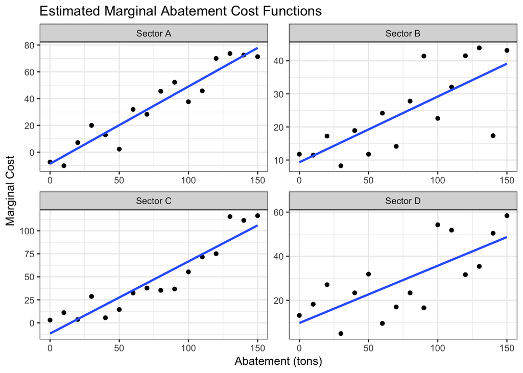

Marginal Cost of Abatement Functions:

- $$MC_A= -8.65 + 0.58(Abatement)$$
- $$MC_B= 9.32 + 0.2 (Abatement)$$
- $$MC_C = -11.66 + 0.78 (Abatement)$$
- $$MC_D = 9.69 + 0.26 (Abatement)$$
2. Using these models and the current level of carbon emissions, derive each sector’s demand curve for carbon emissions. In other words, how much would each sector be willing to pay for the right to pollute the first unit, second unit, etc? Draw these demand curves on a graph. Which sector is willing to pay the most for the first unit of carbon emissions?

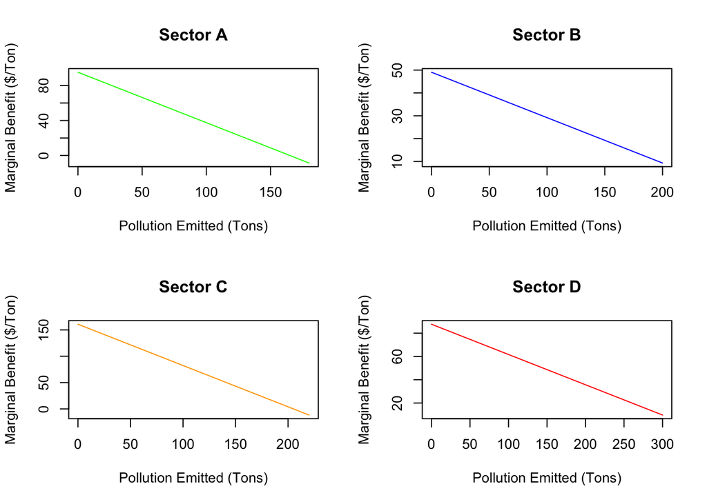

Demand for emission functions:
$$Demand_A = -0.58(Emissions) + 95.19$$
$$Demand_B = -0.2(Emissions) + 49.07$$
$$Demand_C =-0.78(Emissions) + 160.79$$
$$Demand_D = -0.26 (Emissions)+ 87.67$$

- Sector C is willing to pay the most for the first unit of carbon emissions, $160.7868 per Ton.
3. Now focus on country X (which contains sectors A, B, and C). Assume there are no “co-benefits” from carbon abatement (i.e. that there are no local pollutants that are affected by carbon abatement). Suppose to meet the Paris Accord commitments, country X needs to cut all carbon emissions in half. For each of the policy options listed below, derive: (1) the total cost of meeting the target in country X, (2) the cost (or benefit) to each sector, and (3) the tax revenue generated.
1. Cap on carbon. Each sector (A, B, and C) must cut its carbon emissions by 100 tons (thus reducing total emissions from 600 down to 300).
2. Tax on carbon. To emit a ton of carbon in country X, you must pay a tax of $t. You will need to find the tax that accomplishes the desired reduction.
3. Cap and trade. Each sector (A, B, C) is allocated carbon permits equal to their current emissions minus 100 (same as in (a) above), thus achieving the total reduction of 300. Then, these three sectors are allowed to trade with each other. You will need to derive the outcome of that trading.

```r
#part a

demand_A_fn_fixed <- function(x){
  -slope_a*(x) + demand_a_int
}

demand_B_fn_fixed <- function(x){
  -slope_b*(x) + demand_b_int
}

demand_C_fn_fixed <- function(x){
  -slope_c*(x) + demand_c_int
}


polluted_units_C <- 120 #polluted units for sector C

polluted_units_B <- 100 #polluted units for sector B

polluted_units_A <- 80 #polluted units for sector A

abated_units_A <- 100 #abated units for sector A

abated_units_B <- 100 #abated units for sector B

abated_units_C <- 100 #abated units for sector C


##C NUMBERS WITHOUT TAX
pollution_benefit_C <- 120*demand_C_fn_fixed(120) + 0.5*(demand_c_int - demand_C_fn_fixed(120))*120
#13650.87

total_benefit_C <- integrate(demand_C_fn_fixed, 0 , 220)$value

abatement_cost_C <- total_benefit_C - pollution_benefit_C
#2753.63

#A NUMBERS WITHOUT TAX
pollution_benefit_A <- 80*demand_A_fn_fixed(80) + 0.5*(demand_a_int - demand_A_fn_fixed(80))*80
#5769.071

total_benefit_A <- integrate(demand_A_fn_fixed, 0 , 180)$value

abatement_cost_A <- total_benefit_A - pollution_benefit_A
#2019.762

#B NUMBERS WITHOUT TAX
pollution_benefit_B <- 100*demand_B_fn_fixed(100) + 0.5*(demand_b_int - demand_B_fn_fixed(100))*100
#3912.934

total_benefit_B <- integrate(demand_B_fn_fixed, 0 , 200)$value

abatement_cost_B <- total_benefit_B - pollution_benefit_B
#1925.491


######### Aggregated Costs and Benefits #########
abatement_cost_aggregated <- abatement_cost_A + abatement_cost_B + abatement_cost_C
#6698.883

pollution_benefit_aggregated <- pollution_benefit_A + pollution_benefit_B + pollution_benefit_C
#23332.87
```

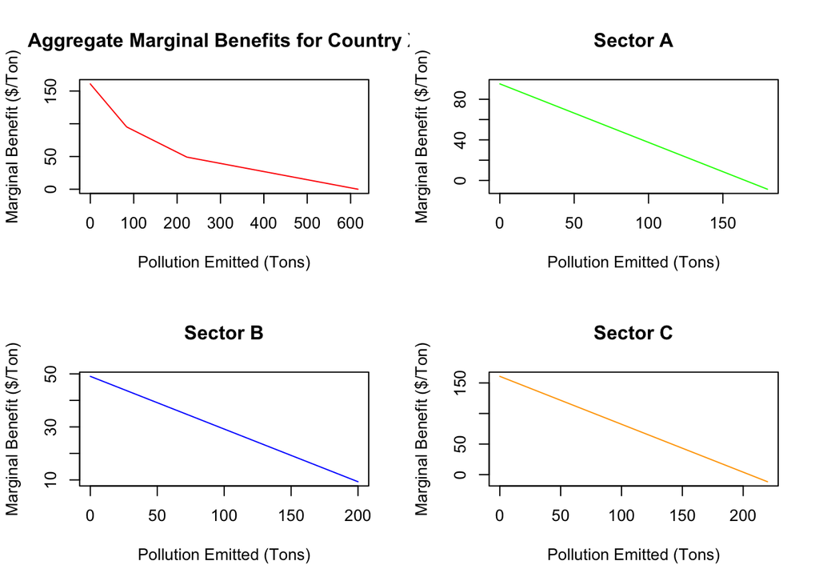

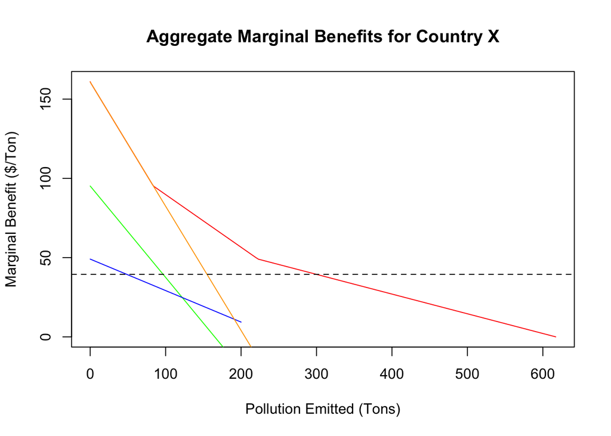

```r
#3b

polluted_units_C_tax <- em_C_fn(tax) #polluted units for sector C
#154.830468933185
polluted_units_B_tax <- em_B_fn(tax) #polluted units for sector B
#48.5044240323858
polluted_units_A_tax <- em_A_fn(tax) #polluted units for sector A
#96.6651070344293
abated_units_A_tax <- (intercept_a - tax)/ -slope_a #abated units for sector A
#83.3348929655707
abated_units_B_tax <- (intercept_b - tax)/ -slope_b #abated units for sector B
#151.495575967614
abated_units_C_tax <- (intercept_c - tax)/ -slope_c #abated units for sector C
#65.169531066815

##C NUMBERS W TAX
pollution_benefit_C_tax <- polluted_units_C_tax*tax + 0.5*polluted_units_C_tax*(demand_c_int-tax)
#15499.57
total_benefit_C_tax <- integrate(demand_C_fn, 0 , 220)$value

abatement_cost_C_tax <- total_benefit_C - pollution_benefit_C
#904.9294

#A NUMBERS WITH TAX
pollution_benefit_A_tax <- polluted_units_A_tax*tax + 0.5*polluted_units_A_tax*(demand_a_int-tax)
#6506.221
total_benefit_A_tax <- integrate(demand_A_fn, 0 , 180)$value

abatement_cost_A_tax <- total_benefit_A - pollution_benefit_A
#1282.612

#B NUMBERS WITH TAX
pollution_benefit_B_tax <- polluted_units_B_tax*tax + 0.5*polluted_units_B_tax*(demand_b_int-tax)
#2146.154
total_benefit_B_tax <- integrate(demand_B_fn, 0 , 200)$value

abatement_cost_B_tax <- total_benefit_B - pollution_benefit_B
#3692.271


######### Aggregated Costs and Benefits #########
abatement_cost_aggregated_tax <- abatement_cost_A_tax + abatement_cost_B_tax + abatement_cost_C_tax
#5879.812

pollution_benefit_aggregated_tax <- pollution_benefit_A + pollution_benefit_B + pollution_benefit_C
#24151.94

tax_revenue_A <- tax*polluted_units_A_tax
#3811.175

tax_revenue_B <- tax*polluted_units_B_tax
#1912.364

tax_revenue_C <- tax*polluted_units_C_tax
#6104.436


tax_revenue <- tax_revenue_A + tax_revenue_B + tax_revenue_C
#11827.97
```

```r
#3c
#B will sell because they get the least benefit from emitting
#A and C will buy because they get more benefit from emitting
# C will buy the most because they have the highest benefit from emitting one more unit.

trading_price <- tax

a_buys <- 80 - em_A_fn(tax)
#-16.66511

b_sells <- 100 - em_B_fn(trading_price)
#51.49558

c_buys <- 120 - em_C_fn(tax)
#-34.83047

c_loses <- -c_buys*tax
#1373.246

b_gains <- b_sells*tax
#2030.294

a_loses <- -a_buys*tax
#657.0482

polluted_units_A_cap <- polluted_units_A_tax
#96.66511
polluted_units_B_cap <- polluted_units_B_tax
#48.50442
polluted_units_C_cap <- polluted_units_C_tax
#154.8305

abated_units_A_cap <- (intercept_a - tax)/ -slope_a #abated units for sector A
#83.3348929655707
abated_units_B_cap <- (intercept_b - tax)/ -slope_b #abated units for sector B
#151.495575967614
abated_units_C_cap <- (intercept_c - tax)/ -slope_c #abated units for sector C
#65.169531066815


# all values stay the same except for the trading units
```

4. Again, without any co-benefits, suppose that country Y (which only has one carbon-emitting sector, D) has no obligation to reduce its emissions. Country X asks country Y to enter the country X carbon market. Doing so would require country Y to put a cap on carbon emissions at its current level of emissions (300 tons), but would then allow country Y to sell carbon offsets to sectors A, B, or C. Are there any incentives for country Y to enter country X’s carbon market and to thus place a voluntary cap on its emissions? Are there any incentives for country X to try to attract country Y into its market?

```r
#4

#em_ag
em_slope_ag_D <- em_slope_a+em_slope_b+em_slope_c + em_slope_d
em_int_ag_D <- em_int_a + em_int_b + em_int_c + em_int_d
em_ag_fn_D <- function(price){
  price*em_slope_ag_D + em_int_ag_D

}

price_slope_ag_D <- function(emissions){
  -em_int_ag_D/em_slope_ag_D + emissions/em_slope_ag_D

}

tax_D <- price_slope_ag_D(600)



polluted_units_D_4 <- em_D_fn(tax_D)
#222.6131
polluted_units_C_4 <- em_C_fn(tax_D) #polluted units for sector C
#167.1088
polluted_units_B_4 <- em_B_fn(tax_D) #polluted units for sector B
#96.92889
polluted_units_A_4 <- em_A_fn(tax_D) #polluted units for sector A
#113.3492

abated_units_A_tax_4 <- (intercept_a - tax_D)/ -slope_a #abated units for sector A
#66.65079
abated_units_B_tax_4 <- (intercept_b - tax_D)/ -slope_b #abated units for sector B
#103.0711
abated_units_C_tax_4 <- (intercept_c - tax_D)/ -slope_c #abated units for sector C
#52.89119
abated_units_D_tax_4 <- (intercept_d - tax_D)/ -slope_d #abated units for sector D
#77.3869

##C NUMBERS W TAX AND SECTOR 4
pollution_benefit_C_tax_4 <- polluted_units_C_4*tax_D + 0.5*polluted_units_C_4*(demand_c_int-tax_D)
#15924.58
total_benefit_C_tax_4 <- integrate(demand_C_fn, 0 , 220)$value

abatement_cost_C_tax_4 <- total_benefit_C_tax_4 - pollution_benefit_C_tax_4
#479.9205

#A NUMBERS WITH TAX AND SECTOR 4
pollution_benefit_A_tax_4 <- polluted_units_A_4*tax_D + 0.5*polluted_units_A_4*(demand_a_int-tax_D)
#7083.733
total_benefit_A_tax_4 <- integrate(demand_A_fn, 0 , 180)$value

abatement_cost_A_tax_4 <- total_benefit_A_tax_4 - pollution_benefit_A_tax_4
#705.0993

#B NUMBERS WITH TAX AND SECTOR 4
pollution_benefit_B_tax_4 <- polluted_units_B_4*tax_D + 0.5*polluted_units_B_4*(demand_b_int-tax_D)
#2146.154
total_benefit_B_tax_4 <- integrate(demand_B_fn, 0 , 200)$value

abatement_cost_B_tax_4 <- total_benefit_B_tax_4 - pollution_benefit_B_tax_4
#2016.081

#D NUMBERS WITH TAX AND SECTOR 4
pollution_benefit_D_tax_4 <- polluted_units_D_4*tax_D + 0.5*polluted_units_D_4*(demand_d_int-tax_D)
#13074.99
total_benefit_D_tax_4 <- integrate(demand_D_fn, 0 , 300)$value

abatement_cost_D_tax_4 <- total_benefit_D_tax_4 - pollution_benefit_D_tax_4
#1528.004


######### Aggregated Costs and Benefits #########
abatement_cost_aggregated_tax <- abatement_cost_A_tax_4 + abatement_cost_B_tax_4 + abatement_cost_C_tax_4 + abatement_cost_D_tax_4
#4729.105

pollution_benefit_aggregated_tax <- pollution_benefit_A_tax_4 + pollution_benefit_B_tax_4 + pollution_benefit_C_tax_4 + pollution_benefit_D_tax_4
#39905.64


#### CAP N TRADE PORTION
trading_price_4 <- tax_D

a_buys_4 <- 80 - em_A_fn(tax_D)
#-33.34921

b_sells_4 <- 100 - em_B_fn(trading_price_4)
#3.071108

c_buys_4 <- 120 - em_C_fn(tax_D)
#-47.10881

d_sells <- 300 - em_D_fn(tax_D)
#77.3869

c_loses_4 <- -c_buys_4*tax_D
#1403.96

b_gains_4 <- b_sells_4*tax_D
#91.52668

a_loses_4 <- -a_buys_4*tax_D
#993.8895

d_gains_4 <- d_sells*tax_D
#2306.323

total_permit_rev_4 <- (d_gains_4 + b_gains_4) - (c_loses_4 + a_loses_4)
```

5. Now assume that every ton of carbon emissions creates 1 ton of local air pollution. Local air pollution causes economic damages (health, environmental, etc.), but only in the country in which it is emitted. Assume there are no local air pollution regulations in either country X or country Y. a. In a carbon cap and trade market that only covers sectors in country X, how much local air pollution would you expect in country X? In country Y? b. If country Y enters the carbon market for country X (as in question 4 above), how much local pollution will there be in country X and country Y? c. What advice can you give country X and country Y about the desirability of allowing international trade of carbon emissions credits?
1. Country X produces: 300 Tons of air pollution Country Y produces: 300 Tons of air pollution

```r
country_x_5b <- polluted_units_A_4 + polluted_units_B_4 + polluted_units_C_4
# 377.3869

country_y_5b <- polluted_units_D_4
#222.6131
```